# Pakistan Drone Attacks Analysis

This tiny dataset which has around 400 rows contains information about drone attacks carried out on pakistan soil for fight aganist terrorism. This dataset is obtained from the website kaggle.

## 1. Loading The Dataset And Required Imports

```r
library(ggplot2)
library(scales)
setwd("E:/MOOC")
attacks <- read.csv("PakistanDroneAttacks.csv",stringsAsFactors=FALSE)
```

## 2. Dimensions Of Dataset

```r
dim(attacks)
```

```
## [1] 403  25
```

## 3. Description of the variables and thier types.

```r
str(attacks)
```

```
## 'data.frame':    403 obs. of  25 variables:
##  $ S.                    : int  1 2 3 4 5 6 7 8 9 10 ...
##  $ Date                  : chr  "Friday, June 18, 2004" "Sunday, May 08, 2005" "Thursday, December 01, 2005" "Friday, January 06, 2006" ...
##  $ Time                  : chr  "22:00" "23:30" "" "" ...
##  $ Location              : chr  "Near Wana" "Mir Ali (Near Afghan Border)" "Haisori- Miran Shah" "Saidgai village- 115km north of Wana" ...
##  $ City                  : chr  "south Waziristan" "North Waziristan" "North Waziristan" "North Waziristan" ...
##  $ Province              : chr  "FATA" "FATA" "FATA" "FATA" ...
##  $ No.of.Strike          : int  1 1 1 1 1 1 1 3 1 1 ...
##  $ Al.Qaeda              : int  NA 1 1 NA NA NA NA NA NA NA ...
##  $ Taliban               : int  1 NA NA NA NA NA NA NA NA NA ...
##  $ Civilians.Min         : int  0 0 0 NA 0 0 0 20 5 NA ...
##  $ Civilians.Max         : int  4 1 1 NA 18 82 2 32 8 NA ...
##  $ Foreigners.Min        : int  NA NA NA NA NA NA NA NA NA NA ...
##  $ Foreigners.Max        : int  NA NA 3 NA NA NA 2 NA 2 NA ...
##  $ Total.Died.Min        : int  NA NA NA NA NA NA NA 20 5 NA ...
##  $ Total.Died.Mix        : int  5 2 5 3 18 82 4 32 10 NA ...
##  $ Injured.Min           : int  NA NA NA NA NA NA NA NA 6 NA ...
##  $ Injured.Max           : int  NA NA 2 2 2 NA 2 15 12 1 ...
##  $ Women.Children        : chr  "N" "N" "" "" ...
##  $ Special.Mention..Site.: chr  "Blast occured in courtyard of the house of long-time friend- the late SherZamanAshrafkhel where Nek Mohammad an"| __truncated__ "Drone struck a car driven by local warlord- killing both him and his passenger Ali-Yemeni" "Explosive occurred at a mud house" "" ...
##  $ Comments              : chr  "Village in Wana" "Civilian killied was Samiullah Khan who was a Local warlord" "No. 3 Al-Qaeda's Leader AbuHamza Rabia killed in a drone attack" "" ...
##  $ References            : chr  "http://archives.dawn.com/2004/06/19/top1.htm" "http://www.msnbc.msn.com/id/7847008/" "http://edition.cnn.com/2005/WORLD/asiapcf/12/03/pakistan.rabia/" "http://www.reuters.com/article/2007/04/27/us-pakistan-violence-idUSISL11111020070427" ...
##  $ Longitude             : num  69.9 70.1 70.1 70.1 71.5 ...
##  $ Latitude              : num  33 33 33 33 34.7 ...
##  $ Temperature.C.        : num  28.475 11.475 7.08 0.535 10.025 ...
##  $ Temperature.F.        : num  83.3 52.7 44.7 33 50 ...
```

## 4. Data Cleaning

```r
attacks$Date <- as.Date(attacks$Date,'%A, %B %d, %Y')
attacks$Year <- format(attacks$Date,'%Y')
attacks$Province <- factor(attacks$Province)
attacks$Tenure <- ifelse(attacks$Year <= 2008,"George W. Bush","Barack Obama")
attacks <- subset(attacks, select = -c(Comments,References,Temperature.C., Temperature.F., Special.Mention..Site.))

# Removing NA Values
attacks$Al.Qaeda[is.na(attacks$Al.Qaeda)] <- 0
attacks$Taliban[is.na(attacks$Taliban)] <- 0
attacks$Civilians.Min[is.na(attacks$Civilians.Min )] <- 0
attacks$Civilians.Max[is.na(attacks$Civilians.Max)] <- 0
attacks$Foreigners.Min[is.na(attacks$Foreigners.Min)] <- 0
attacks$Foreigners.Max[is.na(attacks$Foreigners.Max)] <- 0
attacks$Total.Died.Min[is.na(attacks$Total.Died.Min)] <- 0
attacks$Total.Died.Mix[is.na(attacks$Total.Died.Mix)] <- 0
attacks$Injured.Min[is.na(attacks$Injured.Min)] <- 0
attacks$Injured.Max[is.na(attacks$Injured.Max)] <- 0

str(attacks)
```

```
## 'data.frame':    403 obs. of  22 variables:
##  $ S.            : int  1 2 3 4 5 6 7 8 9 10 ...
##  $ Date          : Date, format: "2004-06-18" "2005-05-08" ...
##  $ Time          : chr  "22:00" "23:30" "" "" ...
##  $ Location      : chr  "Near Wana" "Mir Ali (Near Afghan Border)" "Haisori- Miran Shah" "Saidgai village- 115km north of Wana" ...
##  $ City          : chr  "south Waziristan" "North Waziristan" "North Waziristan" "North Waziristan" ...
##  $ Province      : Factor w/ 3 levels "Balochistan",..: 2 2 2 2 2 2 2 2 2 3 ...
##  $ No.of.Strike  : int  1 1 1 1 1 1 1 3 1 1 ...
##  $ Al.Qaeda      : num  0 1 1 0 0 0 0 0 0 0 ...
##  $ Taliban       : num  1 0 0 0 0 0 0 0 0 0 ...
##  $ Civilians.Min : num  0 0 0 0 0 0 0 20 5 0 ...
##  $ Civilians.Max : num  4 1 1 0 18 82 2 32 8 0 ...
##  $ Foreigners.Min: num  0 0 0 0 0 0 0 0 0 0 ...
##  $ Foreigners.Max: num  0 0 3 0 0 0 2 0 2 0 ...
##  $ Total.Died.Min: num  0 0 0 0 0 0 0 20 5 0 ...
##  $ Total.Died.Mix: num  5 2 5 3 18 82 4 32 10 0 ...
##  $ Injured.Min   : num  0 0 0 0 0 0 0 0 6 0 ...
##  $ Injured.Max   : num  0 0 2 2 2 0 2 15 12 1 ...
##  $ Women.Children: chr  "N" "N" "" "" ...
##  $ Longitude     : num  69.9 70.1 70.1 70.1 71.5 ...
##  $ Latitude      : num  33 33 33 33 34.7 ...
##  $ Year          : chr  "2004" "2005" "2005" "2006" ...
##  $ Tenure        : chr  "George W. Bush" "George W. Bush" "George W. Bush" "George W. Bush" ...
```

## 5. Overall Metrics

In this part of exploration lets explore the total number casualties occurred till date:

```r
total_strikes <- sum(attacks$No.of.Strike)
total_alqaeda <- sum(attacks$Al.Qaeda)
total_taliban <- sum(attacks$Taliban)
total_civilians <- sum(attacks$Civilians.Max)
total_foreigners <- sum(attacks$Foreigners.Max)
total_injured <- sum(attacks$Injured.Max)
total_deaths <- sum(attacks$Total.Died.Mix)
total_Women_Children <- sum(attacks$Women.Children == 'Y')

sprintf("Total Number Of Strikes : %s",total_strikes)
```

```
## [1] "Total Number Of Strikes : 582"
```

```r
sprintf("Total Number Of AL.Qaeda Terrorists Killed: %s",total_alqaeda)
```

```
## [1] "Total Number Of AL.Qaeda Terrorists Killed: 49"
```

```r
sprintf("Total Number Of Taliban Terrorists Killed: %s",total_taliban)
```

```
## [1] "Total Number Of Taliban Terrorists Killed: 657"
```

```r
sprintf("Total Number Of Civilian Casualties: %s",total_civilians)
```

```
## [1] "Total Number Of Civilian Casualties: 2542"
```

```r
sprintf("Total Number Of Foreigners killed: %s",total_foreigners)
```

```
## [1] "Total Number Of Foreigners killed: 372"
```

```r
sprintf("Total Number Of Injured: %s",total_injured)
```

```
## [1] "Total Number Of Injured: 1329"
```

```r
sprintf("Total Number Of Deaths: %s",total_deaths)
```

```
## [1] "Total Number Of Deaths: 3632"
```

```r
sprintf("Total Number Of Strikes That Included Women and Children: %s",total_Women_Children)
```

```
## [1] "Total Number Of Strikes That Included Women and Children: 36"
```

The overall metrics show that a lot of civilian casualties were reported. The civilian casualties contribute to more than 67% of the total deaths.

## 6.Timeline Analysis

Now lets explore the number of drone strikes carried out over year timeline.

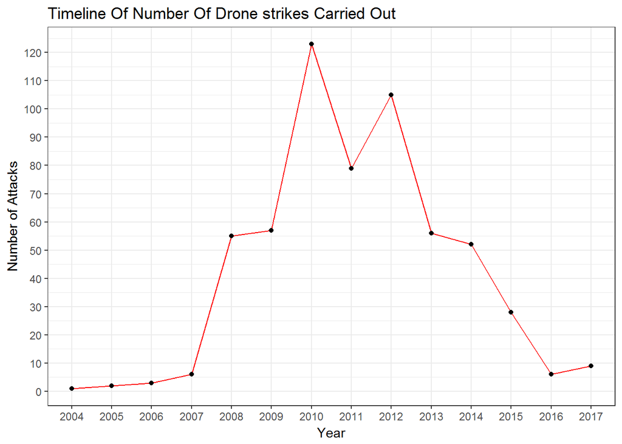

```r
ggplot(attacks,aes(Year,group=1)) +
geom_line(stat = "summary",fun.y=sum,size=0.5,color="red",aes(y=No.of.Strike))+
geom_point(stat = "summary",fun.y=sum,aes(y=No.of.Strike))+
scale_y_continuous(breaks = seq(0,130,10))+
labs(x="Year",y="Number of Attacks",title="Timeline Of Number Of Drone strikes Carried Out")+
theme_bw()
```

The above timeline shows that maximum number of attacks were carried out b/w 2008 and 2015. Now lets explore the civilian casualties and number of terrorists killed over a year timeline.

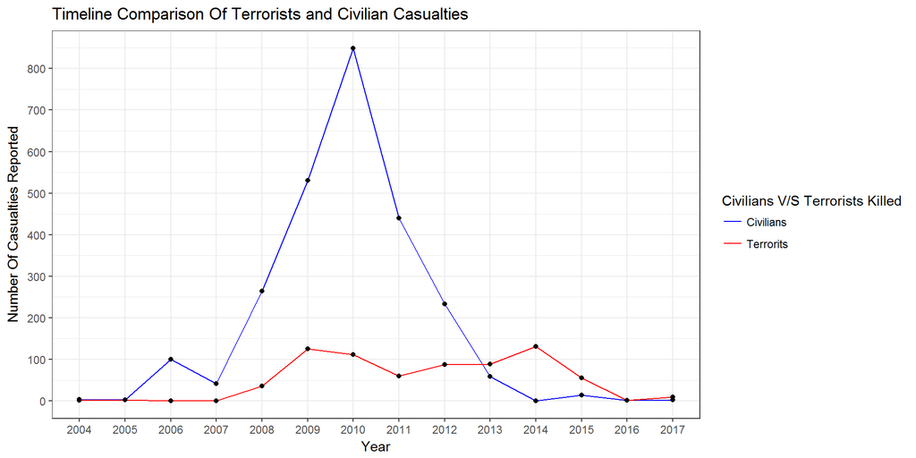

```r
cols <- c("Civilians"="blue","Terrorits"="red")
ggplot(attacks,aes(x=Year,group=1))+
  geom_line(stat = "summary",fun.y=sum,size=0.5,aes(y=Civilians.Max,color="Civilians"))+
  geom_point(stat = "summary",fun.y=sum,aes(y=Civilians.Max))+
  geom_line(stat = "summary",fun.y=sum,size=0.5,aes(y=Al.Qaeda+Taliban,color="Terrorits"))+
  geom_point(stat = "summary",fun.y=sum,aes(y=Al.Qaeda+Taliban))+
  labs(x="Year",y="Number Of Casualties Reported",title="Timeline Comparison Of Terrorists and Civilian Casualties")+
  scale_colour_manual(name="Civilians V/S Terrorists Killed",values=cols)+
  scale_y_continuous(breaks = seq(0,1000,100))+
  theme_bw()
```

The Timeline analysis shows that, till 2012 the number of civilian casualties reported were high when compared to the number of terrorists killed. Now lets explore the number of people injured over a year timeline.

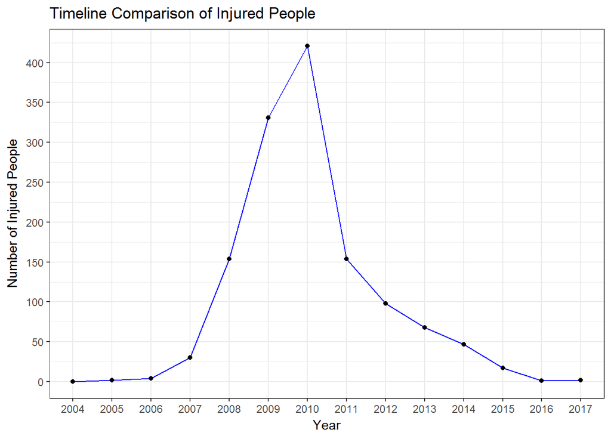

```r
ggplot(attacks,aes(x=Year,group=1))+
  geom_line(stat="summary",fun.y = sum,aes(y=Injured.Max),color= "blue")+
  geom_point(stat="summary",fun.y = sum,aes(y=Injured.Max))+
  scale_y_continuous(breaks = seq(0,500,50))+
  labs(x="Year",y="Number of Injured People",title="Timeline Comparison of Injured People")+
  theme_bw()
```

- The above timeline shows that most number of people were injured in b/w 2008 and 2015, which was the period in which most of the drone strikes were carried out. Now lets take a look at province variable in the dataset, to see which province of Pakistani was targeted the most.

## 7. Province And City Based Exploration.

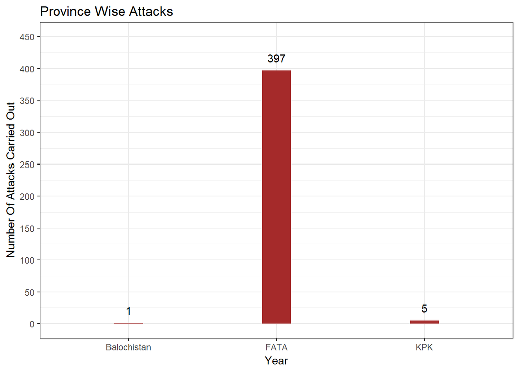

```r
ggplot(attacks,aes(x=Province))+
  geom_bar(width = 0.2,fill="#A52A2A")+
  geom_text(stat='count',aes(label=..count..),vjust=-1)+
  scale_y_continuous(breaks=seq(0,500,50),limits = c(0,450))+
  labs(x="Year",y="Number Of Attacks Carried Out",title="Province Wise Attacks")+
  theme_bw()
```

The Province wise analysis show that most of the attacks were carried out in FATA province because its is a tribal region in Pakistan and its not under much control of Pakistan government and many terrorist groups carry out their operations from this region. Now lets explore the city variable to see which cities were targeted the most.

```r
table(attacks$City)
```

```
##
##      Bajaur  Agency               Bannu           Dalbandin
##                   4                   3                   1
##               Hangu               Hungu              Khyber
##                   1                   1                   1
##       Khyber Agency       Kurram Agency Lower Kurram Agency
##                   5                   3                   1
##    North Waziristan             Orakzai    south waziristan
##                 289                   1                   3
##    south Waziristan    South waziristan    South Waziristan
##                   4                   3                  83
```

The City variable seems to have duplicates of the values “South Waziristan”, Lets rename the duplicate occurrences, so that they point to a single value.

```r
attacks$City <- ifelse(tolower(attacks$City) == "south waziristan","South Waziristan",attacks$City)
table(attacks$City)
```

```
##
##      Bajaur  Agency               Bannu           Dalbandin
##                   4                   3                   1
##               Hangu               Hungu              Khyber
##                   1                   1                   1
##       Khyber Agency       Kurram Agency Lower Kurram Agency
##                   5                   3                   1
##    North Waziristan             Orakzai    South Waziristan
##                 289                   1                  93
```

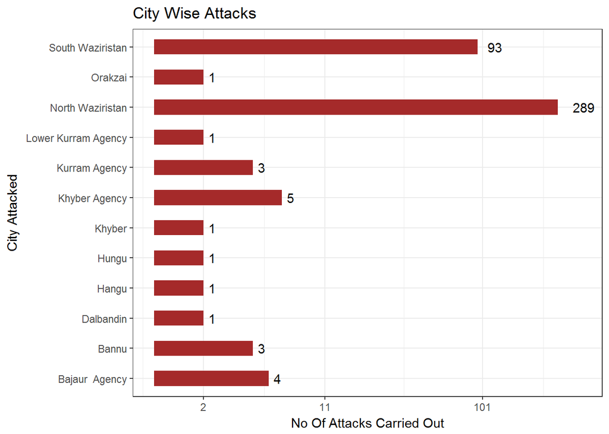

```r
mylog10_trans <- function (base = 10)
{
  trans <- function(x) log(x + 1, base)
  inv <- function(x) base^x
  trans_new(paste0("log-", format(base)), trans, inv, log_breaks(base = base),
            domain = c(1e-100, Inf))
}

ggplot(subset(attacks,attacks$City != ""),aes(City))+
  geom_bar(fill="#A52A2A", width = 0.5)+
  geom_text(stat='count',aes(label=..count..),hjust=-0.7)+
  scale_y_continuous(trans = "mylog10",limits = c(0,400))+
  labs(x="City Attacked",y="No Of Attacks Carried Out",title="City Wise Attacks")+
  coord_flip()+
  theme_bw()
```

- The City analysis shows that, most attacked cities are north and south waziristan. These two cities belong to the FATA province that’s the reason why they are targeted the most.

## 8. Tenure Analysis

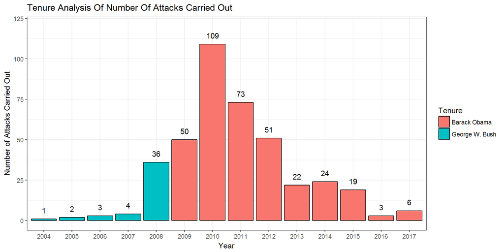

```r
ggplot(subset(attacks,!is.na(attacks$Year)),aes(x=Year,fill=Tenure))+
  geom_bar(color="black")+
  geom_text(stat='count',aes(label=..count..),vjust=-1)+
  scale_y_continuous(limits = c(0,120))+
  labs(x="Year",y="Number of Attacks Carried Out",title="Tenure Analysis Of Number Of Attacks Carried Out")+
  theme_bw()
```

- Under Barack Obama’s Presidency the us security organisations speed up their process to find (osama bin laden) and to neutralize other terrorists groups as well, that’s the reason why we see most of the drone attacks were carried under his term as a president.